# Modelo Predictivo de los salarios de los jugadores de la NBA

Beatriz Quevedo

2020-11-09

## Variables de nba

1. *Player* Nombre del jugador.
2. *Salary* Salario del jugador.
3. *NBA_Country* Nacionalidad del jugador.
4. *NBA_DraftNumber* Número del draft.
5. *Age* Edad del jugador.
6. *Tm* Abreviatura del equipo
7. *G* Partidos jugados.
8. *MP* Minutos jugados.
9. *PER* Eficiencia de jugador.
10. *TS.* Porcentaje de tiro.
11. *X3PAr* % de triples
12. *FTr* % de tiros libres
13. *ORB.* % Rebotes Ofensivos ganados
14. *DRB.* % Rebotes defensivos ganados
15. *TRB.* % Rebotes totales
16. *AST.* % Asistencia
17. *STL.* % Robos
18. *BLK.* % Bloqueos
19. *TOV.* % Robo previo a tiro
20. *USG.* % de participacion en jugadas
21. *OWS* Acciones en ataque acertadas
22. *DWS* Acciones defensivas acertadas
23. *WS* Victorias contribuidas
24. *WS.48* Ratio de contribución por partido
25. *OBPM* +/- rendimiento respecto al equipo (cada 100 jugadas en ataque)
26. *DBPM* +/- rendimiento respecto al equipo (cada 100 jugadas en defensa)
27. *BPM* +/- rendimiento respecto al equipo (cada 100 posesiones generales)
28. *VORP* Valor respecto a jugador involucrado en el cambio

## Tratamiento previo del DataFrame

### Eliminación de los valores nulos, las filas duplicadas y las variables cualitativas.

Se puede apreciar cómo hay ocho valores nulos. Se eliminan las filas mediante na.omit para poder realizar la predicción sin que dichos valores dificulten el proceso.

```r
na <-sapply(nba, function(nba) sum(is.na(nba)))
sum(na)
```

```
## [1] 8
```

```r
nba <- na.omit(nba)
```

```r
nrow(nba[duplicated(nba$Player), ])
```

```
## [1] 2
```

```r
nrow(nba[!duplicated(nba$Player), ])
```

```
## [1] 481
```

Finalmente, se elimina del DataFrame las variables Player, NBA_Country y Tm, ya que son variables cualitativas y no servirán en el estudio, ya que tan solo meterán ruido.

```r
# nba <- select(nba, -Player, -NBA_Country, -Tm)
# (Error in select, no soy capaz de solucionarlo)
```

## Creación del modelo

Se crea un modelo utilizando como variable dependiente el salario y variables dependientes las restantes del DataFrame, y se obtiene un resumen del resultado.

```r
model <- lm(Salary ~  NBA_DraftNumber + Age + G + MP + PER +
              TS. + X3PAr + FTr + ORB. + DRB. + TRB. + AST. + STL. +
              BLK. + TOV. + USG. + OWS + DWS + WS + WS.48 +
              OBPM + DBPM + BPM + VORP,
            data = nba)
summary(model)
```

```
##
## Call:
## lm(formula = Salary ~ NBA_DraftNumber + Age + G + MP + PER +
##     TS. + X3PAr + FTr + ORB. + DRB. + TRB. + AST. + STL. + BLK. +
##     TOV. + USG. + OWS + DWS + WS + WS.48 + OBPM + DBPM + BPM +
##     VORP, data = nba)
##
## Residuals:
##       Min        1Q    Median        3Q       Max
## -15344434  -2975002   -390994   2102049  21682686
##
## Coefficients:
##                 Estimate Std. Error t value Pr(>|t|)
## (Intercept)     -2250339    4899140  -0.459    0.646
## NBA_DraftNumber   -60481      12755  -4.742 2.83e-06 ***
## Age               516821      56511   9.146  < 2e-16 ***
## G                -154411      24983  -6.181 1.41e-09 ***
## MP                  5657       1083   5.224 2.67e-07 ***
## PER              -355059     280566  -1.266    0.206
## TS.             -2162767    5149052  -0.420    0.675
## X3PAr           -3458209    2357905  -1.467    0.143
## FTr              -158470     886960  -0.179    0.858
## ORB.            -1055234     902929  -1.169    0.243
## DRB.             -855005     893502  -0.957    0.339
## TRB.             2006676    1788697   1.122    0.263
## AST.              -19606      47542  -0.412    0.680
## STL.             -196551     421995  -0.466    0.642
## BLK.              110238     318223   0.346    0.729
## TOV.                4208      52692   0.080    0.936
## USG.              169431     104692   1.618    0.106
## OWS             -1271685    4493110  -0.283    0.777
## DWS             -1735775    4518854  -0.384    0.701
## WS               1827796    4498896   0.406    0.685
## WS.48            1914677   11797052   0.162    0.871
## OBPM             1878971    4744860   0.396    0.692
## DBPM             1438902    4660878   0.309    0.758
## BPM             -1295954    4678340  -0.277    0.782
## VORP              629465     633799   0.993    0.321
## ---
## Signif. codes:  0 '***' 0.001 '**' 0.01 '*' 0.05 '.' 0.1 ' ' 1
##
## Residual standard error: 5103000 on 458 degrees of freedom
## Multiple R-squared:  0.5479, Adjusted R-squared:  0.5242
## F-statistic: 23.13 on 24 and 458 DF,  p-value: < 2.2e-16
```

Como resultado vemos que las variables significativas estadísticamente son NBA_DraftNumber, Age, G y MP. Además, el R cuadrado ajustado del 52,42% para esta regresión implica que aproximadamente el 52% de la variación de la variable dependiente Salary se explica por las variables independientes del modelo. Es un valor muy bajo ya que se considera aceptable a partir del 75% como mínimo.

## Selección de las variables del nuevo modelo

Mediante la función stepAIC del paquete MASS se seleccionarán las variables del nuevo modelo de regrsión. En este caso, se utilizará el modelo *Backward*

```r
stepAIC(model, direction = 'backward')
```

```
## Start:  AIC=14944.57
## Salary ~ NBA_DraftNumber + Age + G + MP + PER + TS. + X3PAr +
##     FTr + ORB. + DRB. + TRB. + AST. + STL. + BLK. + TOV. + USG. +
##     OWS + DWS + WS + WS.48 + OBPM + DBPM + BPM + VORP
##
##                   Df  Sum of Sq        RSS   AIC
## - TOV.             1 1.6611e+11 1.1928e+16 14943
## - WS.48            1 6.8601e+11 1.1928e+16 14943
## - FTr              1 8.3134e+11 1.1928e+16 14943
## - BPM              1 1.9984e+12 1.1930e+16 14943
## - OWS              1 2.0862e+12 1.1930e+16 14943
## - DBPM             1 2.4821e+12 1.1930e+16 14943
## - BLK.             1 3.1253e+12 1.1931e+16 14943
## - DWS              1 3.8425e+12 1.1931e+16 14943
## - OBPM             1 4.0840e+12 1.1932e+16 14943
## - WS               1 4.2986e+12 1.1932e+16 14943
## - AST.             1 4.4292e+12 1.1932e+16 14943
## - TS.              1 4.5947e+12 1.1932e+16 14943
## - STL.             1 5.6497e+12 1.1933e+16 14943
## - DRB.             1 2.3847e+13 1.1951e+16 14944
## - VORP             1 2.5688e+13 1.1953e+16 14944
## - TRB.             1 3.2777e+13 1.1960e+16 14944
## - ORB.             1 3.5570e+13 1.1963e+16 14944
## - PER              1 4.1708e+13 1.1969e+16 14944
## <none>                          1.1928e+16 14945
## - X3PAr            1 5.6019e+13 1.1984e+16 14945
## - USG.             1 6.8209e+13 1.1996e+16 14945
## - NBA_DraftNumber  1 5.8559e+14 1.2513e+16 14966
## - MP               1 7.1068e+14 1.2638e+16 14970
## - G                1 9.9486e+14 1.2922e+16 14981
## - Age              1 2.1782e+15 1.4106e+16 15024
##
## Step:  AIC=14942.58
## Salary ~ NBA_DraftNumber + Age + G + MP + PER + TS. + X3PAr +
##     FTr + ORB. + DRB. + TRB. + AST. + STL. + BLK. + USG. + OWS +
##     DWS + WS + WS.48 + OBPM + DBPM + BPM + VORP
##
##                   Df  Sum of Sq        RSS   AIC
## - FTr              1 7.9833e+11 1.1929e+16 14941
## - WS.48            1 8.4655e+11 1.1929e+16 14941
```

[output cut: 295 more lines]

```
##     TRB. + USG. + WS + OBPM
##
##                   Df  Sum of Sq        RSS   AIC
## <none>                          1.2043e+16 14923
## - X3PAr            1 8.1804e+13 1.2124e+16 14924
## - ORB.             1 1.2227e+14 1.2165e+16 14926
## - PER              1 1.3025e+14 1.2173e+16 14926
## - OBPM             1 1.3257e+14 1.2175e+16 14926
## - USG.             1 1.3897e+14 1.2182e+16 14927
## - TRB.             1 2.6687e+14 1.2310e+16 14932
## - NBA_DraftNumber  1 6.5783e+14 1.2700e+16 14947
## - WS               1 6.9027e+14 1.2733e+16 14948
## - MP               1 9.6191e+14 1.3005e+16 14958
## - G                1 1.3853e+15 1.3428e+16 14974
## - Age              1 2.2154e+15 1.4258e+16 15003
```

```
##
## Call:
## lm(formula = Salary ~ NBA_DraftNumber + Age + G + MP + PER +
##     X3PAr + ORB. + TRB. + USG. + WS + OBPM, data = nba)
##
## Coefficients:
##     (Intercept)  NBA_DraftNumber              Age                G
##        -3893333           -62168           511716          -159255
##              MP              PER            X3PAr             ORB.
##            5204          -320540         -3013992          -201694
##            TRB.             USG.               WS             OBPM
##          333889           130873           845245           550301
```

De esta manera se obtiene el nuevo modelo, llamado model2, utilizando el último modelo que ofrece la función stepAIC.

```r
model2 <- lm(formula = Salary ~ NBA_DraftNumber + Age + G + MP + PER + X3PAr + ORB. + TRB. + USG. + WS + OBPM, data = nba)
summary(model2)
```

```
##
## Call:
## lm(formula = Salary ~ NBA_DraftNumber + Age + G + MP + PER +
##     X3PAr + ORB. + TRB. + USG. + WS + OBPM, data = nba)
##
## Residuals:
##       Min        1Q    Median        3Q       Max
## -15532214  -3017494   -365840   2303991  21608017
##
## Coefficients:
##                   Estimate Std. Error t value Pr(>|t|)
## (Intercept)     -3893332.9  2785355.5  -1.398  0.16284
## NBA_DraftNumber   -62168.3    12256.4  -5.072 5.66e-07 ***
## Age               511716.1    54973.9   9.308  < 2e-16 ***
## G                -159255.3    21635.8  -7.361 8.21e-13 ***
## MP                  5204.0      848.4   6.134 1.82e-09 ***
## PER              -320540.0   142016.8  -2.257  0.02446 *
## X3PAr           -3013991.7  1685020.0  -1.789  0.07431 .
## ORB.             -201694.2    92231.2  -2.187  0.02925 *
## TRB.              333889.2   103347.8   3.231  0.00132 **
## USG.              130872.7    56136.5   2.331  0.02016 *
## WS                845245.2   162676.1   5.196 3.04e-07 ***
## OBPM              550301.3   241673.6   2.277  0.02323 *
## ---
## Signif. codes:  0 '***' 0.001 '**' 0.01 '*' 0.05 '.' 0.1 ' ' 1
##
## Residual standard error: 5057000 on 471 degrees of freedom
## Multiple R-squared:  0.5435, Adjusted R-squared:  0.5329
## F-statistic: 50.98 on 11 and 471 DF,  p-value: < 2.2e-16
```

## Multicolinealidad

Para detectar la multicolinealidad de model2 se utilizará el estadistico llamado *variance inflation factor* o *VIF*. Por regla general, si la raíz cuadrada del *VIF* es mayor a 2, es un indicador de multicolinealidad.

```r
vif(model2)
```

```
## NBA_DraftNumber             Age               G              MP             PER
##        1.262696        1.040844        5.394048        8.895257       29.081095
##           X3PAr            ORB.            TRB.            USG.              WS
##        2.755505        3.366046        4.884538        2.016768        3.568490
##            OBPM
##       27.843542
```

```r
sqrt(vif(model2)) > 2
```

```
## NBA_DraftNumber             Age               G              MP             PER
##           FALSE           FALSE            TRUE            TRUE            TRUE
##           X3PAr            ORB.            TRB.            USG.              WS
##           FALSE           FALSE            TRUE           FALSE           FALSE
##            OBPM
##            TRUE
```

```r
model3 <- lm(formula = Salary ~ NBA_DraftNumber + Age + G + MP + PER +
               X3PAr + ORB. + TRB. + USG. + WS, data = nba)
summary(model3)
```

```
##
## Call:
## lm(formula = Salary ~ NBA_DraftNumber + Age + G + MP + PER +
##     X3PAr + ORB. + TRB. + USG. + WS, data = nba)
##
## Residuals:
##       Min        1Q    Median        3Q       Max
## -15291764  -3005260   -372411   2306350  21284443
##
## Coefficients:
##                   Estimate Std. Error t value Pr(>|t|)
## (Intercept)     -7952390.2  2149687.2  -3.699 0.000242 ***
## NBA_DraftNumber   -64685.5    12260.5  -5.276 2.02e-07 ***
## Age               520740.5    55073.3   9.455  < 2e-16 ***
## G                -154782.4    21641.8  -7.152 3.28e-12 ***
## MP                  5409.3      847.4   6.384 4.14e-10 ***
## PER                -5161.9    31533.1  -0.164 0.870040
## X3PAr            -553448.6  1298632.1  -0.426 0.670172
## ORB.             -157047.1    90521.6  -1.735 0.083409 .
## TRB.              199209.7    85124.2   2.340 0.019688 *
## USG.               65328.2    48407.9   1.350 0.177812
## WS                877298.7   162782.8   5.389 1.12e-07 ***
## ---
## Signif. codes:  0 '***' 0.001 '**' 0.01 '*' 0.05 '.' 0.1 ' ' 1
##
## Residual standard error: 5079000 on 472 degrees of freedom
## Multiple R-squared:  0.5385, Adjusted R-squared:  0.5287
## F-statistic: 55.07 on 10 and 472 DF,  p-value: < 2.2e-16
```

```r
vif(model3)
```

```
## NBA_DraftNumber             Age               G              MP             PER
##        1.252424        1.035435        5.349583        8.794841        1.421117
##           X3PAr            ORB.            TRB.            USG.              WS
##        1.622295        3.213919        3.284681        1.486500        3.541769
```

```r
sqrt(vif(model3)) > 2
```

```
## NBA_DraftNumber             Age               G              MP             PER
##           FALSE           FALSE            TRUE            TRUE           FALSE
##           X3PAr            ORB.            TRB.            USG.              WS
##           FALSE           FALSE           FALSE           FALSE           FALSE
```

```r
model4 <- lm(formula = Salary ~ NBA_DraftNumber + Age + G +
               X3PAr + ORB. + TRB. + USG. + WS, data = nba)
summary(model4)
```

```
##
## Call:
## lm(formula = Salary ~ NBA_DraftNumber + Age + G + X3PAr + ORB. +
##     TRB. + USG. + WS, data = nba)
##
## Residuals:
##       Min        1Q    Median        3Q       Max
## -15689594  -3224782   -498247   2299556  21797582
##
## Coefficients:
##                 Estimate Std. Error t value Pr(>|t|)
## (Intercept)     -8912734    2232832  -3.992 7.60e-05 ***
## NBA_DraftNumber   -74655      12648  -5.902 6.83e-09 ***
## Age               505923      57293   8.830  < 2e-16 ***
## G                 -43122      13212  -3.264  0.00118 **
## X3PAr            -155323    1350648  -0.115  0.90849
## ORB.             -192626      94062  -2.048  0.04112 *
## TRB.              120016      87483   1.372  0.17075
## USG.              148359      45510   3.260  0.00119 **
## WS               1473798     131607  11.198  < 2e-16 ***
## ---
## Signif. codes:  0 '***' 0.001 '**' 0.01 '*' 0.05 '.' 0.1 ' ' 1
##
## Residual standard error: 5288000 on 474 degrees of freedom
## Multiple R-squared:  0.4975, Adjusted R-squared:  0.4891
## F-statistic: 58.67 on 8 and 474 DF,  p-value: < 2.2e-16
```

El R cuadrado ajustado se ha vuelto a ver reducido, pero sin embargo, si repetimos por última vez la función vif(), se puede observar cómo ya no existe multicolinealidad.

```r
vif(model4)
```

```
## NBA_DraftNumber             Age               G           X3PAr            ORB.
##        1.229464        1.033614        1.839131        1.618650        3.200858
##            TRB.            USG.              WS
##        3.199976        1.211898        2.135367
```

```r
sqrt(vif(model4)) > 2
```

```
## NBA_DraftNumber             Age               G           X3PAr            ORB.
##           FALSE           FALSE           FALSE           FALSE           FALSE
##            TRB.            USG.              WS
##           FALSE           FALSE           FALSE
```

## Normalidad del modelo

Si la vble dependiente esta distribuida normalmente para un numero fijo de valores predictivos, entonces los valores residuales deberian distribuirse con una media = 0. La normal Q-Q Plot (el gráfico que aparece a continuación) es un plot de probabilidad de los residuos estandarizados contra los valores bajo una supuesta normalidad. Se cumple la hipoteses de normalidad si los valores siguen una linea de 45º con los ejes.

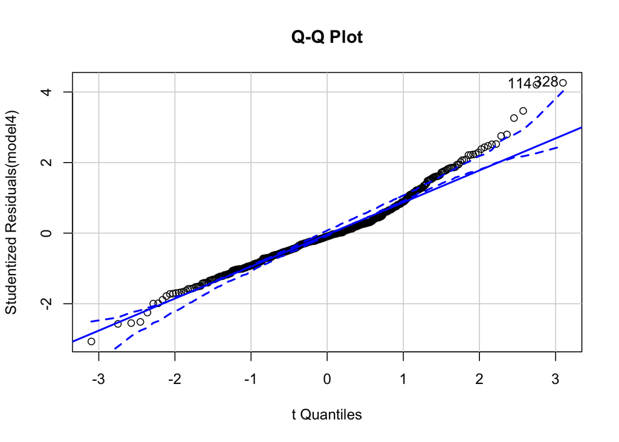

```
## 114 328
## 112 326
```

```r
qqPlot(model4, labels=row.names(nba), id.method="identify",
       simulate=TRUE, main="Q-Q Plot")
```

Por lo tanto, como se puede observar en la gráfica, hay varios valores outliers que pueden estar metiendo ruido y alterando la normalidad.

Se estudiará, por ejemplo, el valor 328. Este valor pertenece a Gordon Hayward, cuyo salario es de 29.727.900$.

```r
nba[326,]
```

```
##             Player   Salary NBA_Country NBA_DraftNumber Age  Tm G MP PER TS.
## 328 Gordon Hayward 29727900         USA               9  27 BOS 1  5 7.4 0.5
##     X3PAr FTr ORB. DRB. TRB. AST. STL. BLK. TOV. USG. OWS DWS WS WS.48 OBPM
## 328   0.5   0    0 21.6   11    0    0    0    0 17.9   0   0  0 0.057 -5.9
##     DBPM   BPM VORP
## 328   -6 -11.9    0
```

Al realizar la función fitted() se aprecia cómo la función está estimando por debajo el salario que debería obtener Hayward, ya que según el modelo predictivo éste debería ganar 8.045.214.

```r
fitted(model)[326]
```

```
##     328
## 8045214
```

Encontramos un total de 26 outliers.

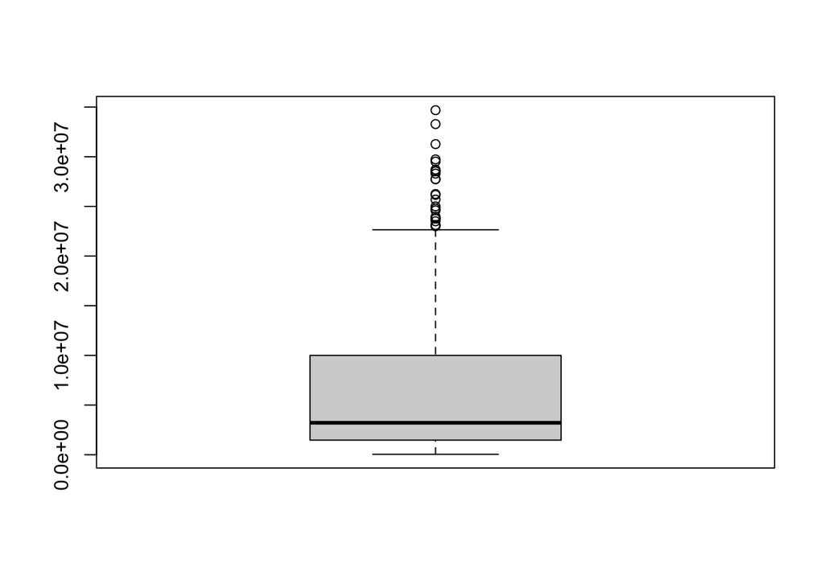

```r
outliers <- boxplot(nba$Salary)$out
```

```r
nba <- nba[-326,]
nba <- nba[-112,]
```

Realizando un modelo sin estos outliers, se produce una mejora el R cuadrado ajustado.

```r
model5 <- lm(formula = Salary ~ NBA_DraftNumber + Age + G +
               X3PAr + ORB. + TRB. + USG. + WS, data = nba)
summary(model5)
```

```
##
## Call:
## lm(formula = Salary ~ NBA_DraftNumber + Age + G + X3PAr + ORB. +
##     TRB. + USG. + WS, data = nba)
##
## Residuals:
##       Min        1Q    Median        3Q       Max
## -15551711  -3153412   -484008   2222968  18395056
##
## Coefficients:
##                 Estimate Std. Error t value Pr(>|t|)
## (Intercept)     -8610713    2158135  -3.990 7.66e-05 ***
## NBA_DraftNumber   -73253      12243  -5.983 4.32e-09 ***
## Age               487245      55394   8.796  < 2e-16 ***
## G                 -35929      12821  -2.802  0.00528 **
## X3PAr            -202638    1303491  -0.155  0.87653
## ORB.             -145056      91215  -1.590  0.11244
## TRB.               75011      84802   0.885  0.37685
## USG.              144724      43935   3.294  0.00106 **
## WS               1470819     126961  11.585  < 2e-16 ***
## ---
## Signif. codes:  0 '***' 0.001 '**' 0.01 '*' 0.05 '.' 0.1 ' ' 1
##
## Residual standard error: 5102000 on 472 degrees of freedom
## Multiple R-squared:  0.5133, Adjusted R-squared:  0.505
## F-statistic: 62.22 on 8 and 472 DF,  p-value: < 2.2e-16
```

## Comparación de los modelos

Mediante el uso de la función BIC() comparamos el primer modelo, *model* con *model4*.

```r
BIC(model, model4)
```

```
##        df      BIC
## model  26 16425.94
## model4 10 16378.05
```

Como el BIC del último modelo es menor, podemos afirmar que ha mejorado levemente la predicción del primer modelo.

## Validación

La finción gvlma() proporciona una validación global de las hipótesis del modelo lineal.

```r
validation <- gvlma(model4)
summary(validation)
```

```
##
## Call:
## lm(formula = Salary ~ NBA_DraftNumber + Age + G + X3PAr + ORB. +
##     TRB. + USG. + WS, data = nba)
##
## Residuals:
##       Min        1Q    Median        3Q       Max
## -15689594  -3224782   -498247   2299556  21797582
##
## Coefficients:
##                 Estimate Std. Error t value Pr(>|t|)
## (Intercept)     -8912734    2232832  -3.992 7.60e-05 ***
## NBA_DraftNumber   -74655      12648  -5.902 6.83e-09 ***
## Age               505923      57293   8.830  < 2e-16 ***
## G                 -43122      13212  -3.264  0.00118 **
## X3PAr            -155323    1350648  -0.115  0.90849
## ORB.             -192626      94062  -2.048  0.04112 *
## TRB.              120016      87483   1.372  0.17075
## USG.              148359      45510   3.260  0.00119 **
## WS               1473798     131607  11.198  < 2e-16 ***
## ---
## Signif. codes:  0 '***' 0.001 '**' 0.01 '*' 0.05 '.' 0.1 ' ' 1
##
## Residual standard error: 5288000 on 474 degrees of freedom
## Multiple R-squared:  0.4975, Adjusted R-squared:  0.4891
## F-statistic: 58.67 on 8 and 474 DF,  p-value: < 2.2e-16
##
##
## ASSESSMENT OF THE LINEAR MODEL ASSUMPTIONS
## USING THE GLOBAL TEST ON 4 DEGREES-OF-FREEDOM:
## Level of Significance =  0.05
##
## Call:
##  gvlma(x = model4)
##
##                      Value   p-value                   Decision
## Global Stat        85.5073 0.000e+00 Assumptions NOT satisfied!
## Skewness           38.5697 5.283e-10 Assumptions NOT satisfied!
## Kurtosis           39.8900 2.687e-10 Assumptions NOT satisfied!
## Link Function       6.3985 1.142e-02 Assumptions NOT satisfied!
## Heteroscedasticity  0.6492 4.204e-01    Assumptions acceptable.
```

Gracias a esta validación se puede apreciar cómo cumple la hipótesis de heterocedasticidad.

Para finalizar, se realiza un muestreo aleatorio simple del DataFrame.

```r
set.seed(1234)
n = 10
muestreo <- sample(1:nrow(nba), size = n, replace = FALSE)
nba_muestreo <- nba[muestreo, ]
nba_muestreo
```

```
##               Player   Salary NBA_Country NBA_DraftNumber Age  Tm  G   MP  PER
## 287     Jarrett Jack  2328652         USA              22  34 NYK 58 1483 11.2
## 340   Furkan Korkmaz  1465920      Turkey              26  20 PHI 12   69  6.5
## 410       Damion Lee    92160         USA              62  25 ATL 12  321 12.9
## 103   Reggie Jackson 16000000         USA              24  27 DET 41 1084 15.5
## 113      Paul Zipser  1312611     Germany              48  23 CHI 54  824  5.2
## 397   David Stockton   148318         USA              62  26 UTA  2    6 31.4
## 136 Nicolas Brussino  1312611   Argentina              62  24 ATL  4   10 -4.6
## 426    Cheick Diallo  1312611        Mali              33  21 NOP 48  538 17.4
## 404 Dante Cunningham  2300000         USA              33  30 TOT 70 1499  9.7
## 392  DeAndre' Bembry  1567200         USA              21  23 ATL 23  395  6.2
##       TS. X3PAr   FTr ORB. DRB. TRB. AST. STL. BLK. TOV. USG.  OWS DWS   WS
## 287 0.487 0.193 0.167  1.5 11.9  6.7 31.3  1.2  0.2 19.9 16.5  0.3 0.7  1.0
## 340 0.446 0.625 0.167  3.3 13.6  8.6  6.0  1.4  1.2  7.2 17.2  0.0 0.1  0.0
## 410 0.496 0.387 0.210  3.1 15.7  9.4 11.7  2.6  0.3  7.8 19.2  0.1 0.3  0.4
```

[output cut: 18 more lines]

Este muestreo es utilizado en un modelo predictivo utilizando *model4*

```r
nba_salario <- predict(model4, newdata = nba_muestreo)
nba_salario
```

```
##      287      340      410      103      113      397      136      426
##  8552076  1598401  2498165  7752919 -1178831  4829703  1579977  3099340
##      404      392
##  5863425  2709483
```

Así se puede ver que el modelo tiende a sobreestimar los salarios de los jugadores. Este resultado indica que el modelo no es óptimo para predecir la variable dependiente.